# Estimating synthetic lethal interactions for PDAC

# 3 Construct a Synthetic Lethality Network for PDAC

## 3.1 Define a consensus interaction dataset

All formatted datasets are combined and summarised.

```r
#combine dfs
sl_all <- rbind(sl_human, sl_cocanet, sl_crispr, sl_shen)

#summarise and remove duplicates
sl_all <- sl_all %>%
  mutate(interaction = paste0(GeneASymbol, "_", GeneBSymbol)) %>%
  group_by(GeneASymbol, GeneBSymbol) %>%
  summarise(count = n(),
            experimental = max(experimental)) %>%
  mutate(Score = count*experimental)
  #mutate(Score = experimental)
  #filter(Score > 1) %>%

#filter genes that are PDAC drivers
sl_all_scored <- sl_all %>%
  #only genes which are interacting with drivers of PDAC are retained in the dataset
  filter((GeneASymbol %in% pdac_driver$SYMBOL | GeneBSymbol %in% pdac_driver$SYMBOL)) %>%
  #only genes which have not been reported to be core essential in CRISPRx based screens are retained, thereby reducing noise
  filter(!(GeneASymbol %in% ceg$gene | GeneBSymbol %in% ceg$gene))
```

## 3.2 Draw a Synthetic Lethality Network for PDAC

Combination of datasets leads to 2328 overall high-confidence interactions. 111 of these interactions are affecting PDAC driver genes. These can be mapped.  
The following network shows driver genes (yellow) and partner genes (black) as nodes. The edges symbolize synthetic lethal interactions, which are colored depending on their source/“experimental”-Score. Red edges are based on the syn_lethal database, blue edges are based on the Shen et al. dataset. All residual links are colored in green

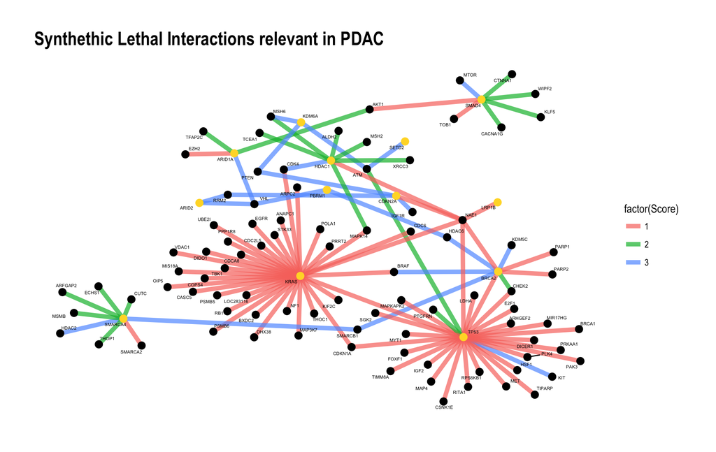

```r
#Genes in the dataset are either "drivers" or potential "lethal partners". A table with this annotation is created.
attributes <- tibble(gene = c(sl_all_scored$GeneASymbol, sl_all_scored$GeneBSymbol) %>% unique()) %>%
  mutate(role = if_else(gene %in% pdac_driver$SYMBOL, "driver", "partner"),
         color = if_else(role == "driver", RColorBrewer::brewer.pal(6, "Set2")[6], "black"))


sl_all_scored %>%
  as_tibble() %>%
  #mutate(Score = factor(Score)) %>%
  #filter(Score > 2) %>%
  graph_from_data_frame(directed = FALSE, vertices=attributes) -> temp

#Create a custom color scale
library(RColorBrewer)
mycolors <- brewer.pal(8, "Set3")[5:7]
names(mycolors) <- levels(sl_all_scored$Score)
colscale <- scale_colour_manual(name = "Score",values = mycolors)
#V(temp)$color <- ifelse(V(temp)$role == "driver", "lightblue", "orange")

ggraph(temp, layout = 'dh') + #lgl, drl, graphopt, kk
  geom_edge_fan(aes(colour = factor(Score)), edge_alpha = 0.7, edge_width = 2, show.legend = TRUE) +
  #guides(edge_alpha = "none", edge_width = "none") +
  #scale_edge_colour_gradientn(limits = c(1, 6), colors = rev(c("firebrick2", "dodgerblue2"))) +
  geom_node_point(color = factor(attributes$color), size = 3, alpha = 1) +
  geom_node_text(aes(label = name), repel = TRUE, size = 1.5) +
  theme_graph() +
  labs(title = "Synthethic Lethal Interactions relevant in PDAC")
```

```r
partners.no <- attributes %>%
  filter(role == "partner") %>%
  nrow()
```

## 3.3 List interacting driver genes

```r
attributes %>%
  filter(role == "driver") %>%
  .$gene
```

```
##  [1] "ARID1A"  "ARID2"   "BRCA2"   "CDKN2A"  "HDAC1"   "KDM6A"   "KRAS"
##  [8] "LRP1B"   "PBRM1"   "SMAD4"   "SMARCA4" "TP53"    "SETD2"
```

# 4 Construct a network of sequencing based genetic interactions

Recent work by Mina et al., doi: https://doi.org/10.1016/j.ccell.2017.06.010 identified co-occuring and mutually exclusive genetic alterations in a pan-cancer analysis. This dataset gives high-confidence information about relevant genetic interactions in tumors. Targeting interacting driver genes might reduce cell fitness in PDAC as well and is a second approach to identify target-genes for a highly active focused CRISPR library used PDAC organoid studies.

## 4.1 Load data of pan-cancer genetic interactions

```r
sfe <-  read_excel("~/zurich/local_data/synthetic_lethality/SFE_pairs_all1-s2.0-S1535610817302611-mmc3 (1).xls",
    skip = 2) %>%
  filter(int_type == "MUTATION MUTATION") %>%
  #genes that are reported to be core-essential are removed from the network
  filter(!(SFE_1 %in% ceg$gene | SFE_2 %in% ceg$gene))
```

## 4.2 Save datasets

```r
save(sfe, file = "sequencing_input.Rdata")
```

## 4.3 Load datasets

```r
load("sequencing_input.Rdata")
```

## 4.4 Show the pan-cancer network of sequencing based genetic interactions

```
## Using `nicely` as default layout
```

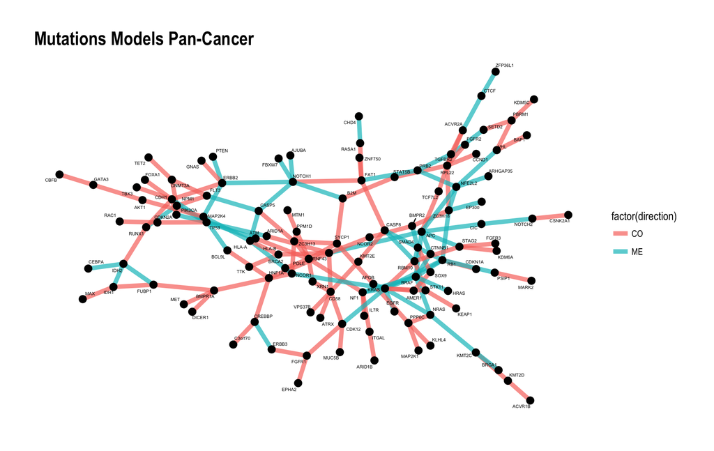

```r
sfe %>%
  graph_from_data_frame(directed = FALSE) -> temp_graph

#vertex_attr(temp_graph, 'name') = if_else(vertex_attr(temp_graph, 'name') %in% test, vertex_attr(temp_graph, 'name'), "")

ggraph(temp_graph, layout = )+
    geom_edge_fan(aes(colour = factor(direction)), edge_alpha = 0.7, edge_width = 2, show.legend = TRUE) +
  #guides(edge_alpha = "none", edge_width = "none") +
  #scale_edge_colour_gradientn(limits = c(1, 6), colors = rev(c("firebrick2", "dodgerblue2"))) +
  geom_node_point(aes(), size = 3, alpha = 1, show.legend = FALSE) +
  geom_node_text(data = NULL, aes(label = name), repel = TRUE, size = 1.5) +
  theme_graph() +
  labs(title = "Mutations Models Pan-Cancer")
```

## 4.5 Show a PDAC relevant network of sequencing based genetic interactions

```
## Using `nicely` as default layout
```

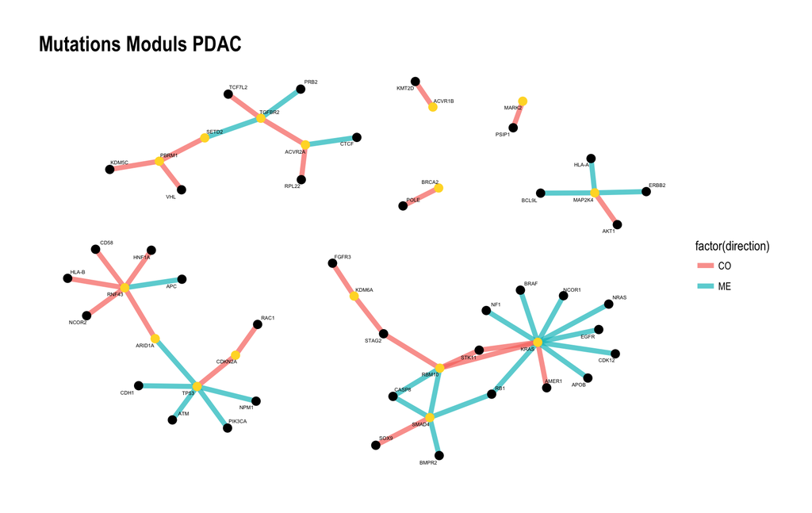

```r
sfe %>%
  filter((SFE_1 %in% pdac_driver$SYMBOL | SFE_2 %in% pdac_driver$SYMBOL)) -> temp

attributes <- tibble(gene = c(temp$SFE_1, temp$SFE_2) %>% unique()) %>%
  mutate(role = if_else(gene %in% pdac_driver$SYMBOL, "driver", "partner"),
         color = if_else(role == "driver", RColorBrewer::brewer.pal(6, "Set2")[6], "black"))

temp %>%
  graph_from_data_frame(directed = FALSE) -> temp_graph

ggraph(temp_graph, layout = )+
    geom_edge_fan(aes(colour = factor(direction)), edge_alpha = 0.7, edge_width = 2, show.legend = TRUE) +
  #guides(edge_alpha = "none", edge_width = "none") +
  #scale_edge_colour_gradientn(limits = c(1, 6), colors = rev(c("firebrick2", "dodgerblue2"))) +
  geom_node_point(color = attributes$color, size = 3, alpha = 1) +
  geom_node_text(data = NULL, aes(label = name), repel = TRUE, size = 1.5) +
  theme_graph() +
  labs(title = "Mutations Moduls PDAC")
```

# 5 Build a combined network of genetic interactions

Both synthetic lethality and sequencing based interaction data can be combined to build a graph of PDAC relevant genes for further testing.

## 5.1 Unify the dataset

```r
#start with the sl data
#combine dfs
sl_all <- rbind(sl_human, sl_cocanet, sl_crispr, sl_shen)

#summarise keep duplicates this time
sl_all <- sl_all %>%
  mutate(interaction = paste0(GeneASymbol, "_", GeneBSymbol)) %>%
  #group_by(GeneASymbol, GeneBSymbol) %>%
  #summarise(count = n(),
  #          experimental = max(experimental)) %>%
  #mutate(Score = count*experimental)
  mutate(Score = paste0("Experimental evidence ", experimental))
  #filter(Score > 1) %>%

#filter genes that are PDAC drivers
sl_all <- sl_all %>%
  #only genes which are interacting with drivers of PDAC are retained in the dataset
  filter((GeneASymbol %in% pdac_driver$SYMBOL | GeneBSymbol %in% pdac_driver$SYMBOL)) %>%
  #only genes which have not been reported to be core essential in CRISPRx based screens are retained, thereby reducing noise
  filter(!(GeneASymbol %in% ceg$gene | GeneBSymbol %in% ceg$gene))

#add the sfe module data
sfe_all <- sfe %>%
  filter((SFE_1 %in% pdac_driver$SYMBOL | SFE_2 %in% pdac_driver$SYMBOL)) %>%
  rename(GeneASymbol = SFE_1,
         GeneBSymbol = SFE_2) %>%
  mutate(Score = paste0("Sequencing evidence ", direction)) %>%
  select(GeneASymbol, GeneBSymbol, Score) %>%
  mutate(Evidence = "sequencing",
         experimental = 3,
         source = "sfe",
         interaction = paste0(GeneASymbol, "_", GeneBSymbol))

gi_all <- rbind(sl_all, sfe_all)
```

## 5.2 Draw the combined network

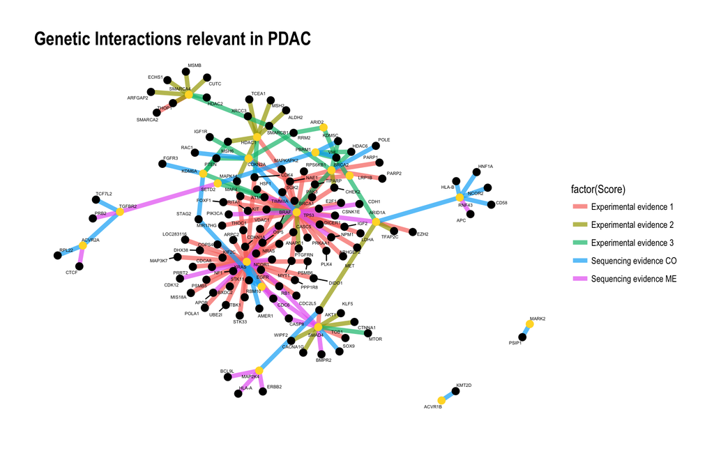

```r
#Genes in the dataset are either "drivers" or potential "lethal partners". A table with this annotation is created.
attributes <- tibble(gene = c(gi_all$GeneASymbol, gi_all$GeneBSymbol) %>% unique()) %>%
  mutate(role = if_else(gene %in% pdac_driver$SYMBOL, "driver", "partner"),
         color = if_else(role == "driver", RColorBrewer::brewer.pal(6, "Set2")[6], "black"))


gi_all %>%
  as_tibble() %>%
  #mutate(Score = factor(Score)) %>%
  #filter(Score > 2) %>%
  graph_from_data_frame(directed = FALSE) -> temp

#Create a custom color scale
library(RColorBrewer)
mycolors <- brewer.pal(8, "Set3")[5:7]
names(mycolors) <- levels(sl_all_scored$Score)
colscale <- scale_colour_manual(name = "Score",values = mycolors)
#V(temp)$color <- ifelse(V(temp)$role == "driver", "lightblue", "orange")

ggraph(temp, layout = 'graphopt') + #lgl, drl, graphopt, kk
  geom_edge_fan(aes(colour = factor(Score)), edge_alpha = 0.7, edge_width = 2, show.legend = TRUE) +
  #guides(edge_alpha = "none", edge_width = "none") +
  #scale_edge_colour_gradientn(limits = c(1, 6), colors = rev(c("firebrick2", "dodgerblue2"))) +
  geom_node_point(color = attributes$color, size = 3, alpha = 1) +
  geom_node_text(aes(label = name), repel = TRUE, size = 1.5) +
  theme_graph() +
  labs(title = "Genetic Interactions relevant in PDAC")
```

```r
partners.no <- attributes %>%
  filter(role == "partner") %>%
  nrow()
```

## 5.3 Save network data

```r
write_excel_csv(gi_all, "genetic_interactions_pdac_NR.csv")
```